# WildFire_Project Summary Paper

Arundhati G., Zhongyang H., Adarsh K., Sumanth N.

2022-04-04

The summary is organized in following chapters:  
1. Chapter 1: Introduction of Project & SMART Questions  
2. Chapter 2: Previous Research  
3. Chapter 3: Description of the Data set  
4. Chapter 4: EDA of Observations of Wildfires  
5. Chapter 5: EDA of Annual and Monthly Statistics  
6. Chapter 6: Hypothesis Testing  
7. Chapter 7: Correlation and Linear Model  
8. Chapter 8: Conclusion

# Chapter 1: Introduction of Project & SMART Questions

California continues to experience longer wildfire seasons due to climate change. In the past couple of years, as the world navigated through the COVID-19 outbreak, Californians also had to deal with large wildfires. With rising concerns over climate change and its impact on our lives, our research aimed to study the causes and effects of wildfires and increase awareness of the issue. With an abundance of environmental data out there, we hoped to use some of it to come up with recommendations in terms of budget allocation and identify particular pain points.

Listed below are our SMART Questions. Due to the nature of our data, we wanted to investigate the conditions and causes of each wildfire to help figure out potential mitigations. We also wanted to look at how the budget played a factor in the frequency/intensity of the wildfires. With this initial look into how different variables play a factor into wildfires, we hoped to understand a bit more about what causes them and what recommendations to propose for mitigating them.

1. Did the annual number of wildfires in California increase with an increase in the temperature between 1992-2015?
2. Did higher precipitation levels result in a smaller or fewer number of wildfires in California between 1992-2015?
3. Did a lower fire suppression expenditure in California result in larger wildfires between 1992-2015?
4. Did lower levels of soil moisture in California result in larger or more frequent wildfires between 1992-2015?

# Chapter 2: Previous Research

One of the first papers we looked at was “Climate change and growth scenarios for California wildfire” which talked about how population growth may affect the the frequency and intensity of wildfires. According to the authors Westerling, Bryant, and Preisler in human-induced climatic change and the increasing population in California are likely to impact large wildfires in the area directly. The research studied different scenarios for future population growth and wildland-urban interface relative to housing density and assessed the results for thirty years. In every scenario, there was an anticipated increased wildfire burned area which grew over time if the human-induced climatic change continues at the same intensity.

In the next paper, A Framework for Risk Assessment and Optimal Line Upgrade Selection to Mitigate Wildfire Risk the authors Sofia Taylor and Line A. Roald claim that overhead lines pose some risk to igniting wildfires, so they outline different factors that contribute to whether or not overhead lines should be converted to underground cables to mitigate fire risk. They developed a model to weigh these factors for different overhead lines and recommended which to put underground. This is relative to our topic because we investigated the amount of wildfires that were caused by equipment use, which ranked higher than we anticipated.

Last but not least, we read about a paper where the researchers How-Hang Liu, Ronald Y. Chang, Yi-Ying Chen, and I-Kang Fu proposed the use of IoT (Internet of Things) sensors to detect wildfires by monitoring wind speed, soil wetness, biomass, and other factors to identify when a fire has started. We also investigated soil moisture to see if it was a contributing factor to the intensity or frequency of wildfires.

References Westerling, A.L., Bryant, B.P., Preisler, H.K. et al. Climate change and growth scenarios for California wildfire. Climatic Change 109, 445–463 (2011). https://doi.org/10.1007/s10584-011-0329-9  
Taylor, Sofia, Roald, A. Line. A Framework for Risk Assessment and Optimal Line Upgrade Selection to Mitigate Wildfire Risk. Arxiv (2021). https://arxiv.org/abs/2110.07348  
Liu, How-Hang, Chang, Ronald Y., Chen, Yi-Ying, Fu, I-Kang. Sensor-Based Satellite IoT for Early Wildfire Detection. Arxiv (2021). https://arxiv.org/abs/2109.10505

```r
WildfireData <- read.csv('final_wildfire.csv')
summary_nature=read.csv('summary_nature.csv')
summary_peoplecaused=read.csv('summary_peoplecaused.csv')
fire_budget  <- read.csv("fire_suppression.csv")
```

```r
Avg_Temp <- WildfireData$tair_day_livneh_vic
Avg_SoilMoisture <- WildfireData$soilmoist1_day_livneh_vic
Avg_Rainfall <- WildfireData$rainfall_day_livneh_vic
```

# Chapter 3: Description of Dataset

We also hypothesized that the California state budget for fire suppression would be an interesting factor to observe over the years. Did increased/decreased spending have an impact on the frequency/intensity of wildfires over the years? We looked to answer this question in hopes of understanding how state government efforts were helping (or not) the wildfire situation in California. To incorporate this dataset into our main dataset, we merely merged them by year.

With the aforementioned datasets, we found that, while they were somewhat useful for our analysis, they weren’t as granular as we hoped they would be. For example, the dataset containing California’s yearly budget for fire suppression could have also included how the money was partitioned across different causes/uses. That way, we would be able to provide more detailed recommendations on where some funds should be redistributed. As it stands, knowing how much money is being dedicated to combating wildfires in itself is not incredibly useful.

In addition, the data dictionaries for our datasets regarding air temperature and soil moisture didn’t really detail what units the data was recorded in. Since we were dealing with data from California in the United States, we could only assume that Fahrenheit was used but even then, the measurements seemed a bit lower than expected. As for soil moisture, we had to look into what the common unit for this metric was, which turned out to be in bars.

Additional information that would have been useful is data about human patterns and activities and how they have potentially impacted the frequency/intensity of wildfires over the years. Studying the population growth and housing density in California over time in comparison to incidents of wildfires can provide increased understanding of the causes of human-caused wildfires.

## 3.1 Summary for dataset

```r
temp=str_remove(fire_budget$Budget,"[$]")
temp=str_remove_all(temp,"[,]")
fire_budget$Budget=as.numeric(temp)

temp=str_remove(WildfireData$Budget,"[$]")
temp=str_remove_all(temp,"[,]")
WildfireData$Budget=as.numeric(temp)

xkablesummary(WildfireData)
```

Table: Statistics summary.

|  | X | Year | DISCOVERY_DOY | Budget | DISCOVERY_DATE | STAT_CAUSE_CODE | STAT_CAUSE_DESCR | CONT_DATE | CONT_DOY | FIRE_SIZE | FIRE_SIZE_CLASS | STATE | existDay | tair_day_livneh_vic | month | soilmoist1_day_livneh_vic | rainfall_day_livneh_vic |
| --- | --- | --- | --- | --- | --- | --- | --- | --- | --- | --- | --- | --- | --- | --- | --- | --- | --- |
| Min | Min. : 1 | Min. :1992 | Min. : 1.0 | Min. : 43800000 | Min. :2448623 | Min. : 1.000 | Length:189550 | Min. :2448623 | Min. : 1.0 | Min. : 0.00 | Length:189550 | Length:189550 | Min. : 0.00 | Min. :-3.95 | Min. : 1.000 | Min. :10.51 | Min. : 0.000 |
| Q1 | 1st Qu.: 47388 | 1st Qu.:1997 | 1st Qu.:164.0 | 1st Qu.: 85591000 | 1st Qu.:2450625 | 1st Qu.: 2.000 | Class :character | 1st Qu.:2451363 | 1st Qu.:169.0 | 1st Qu.: 0.10 | Class :character | Class :character | 1st Qu.: 0.00 | 1st Qu.:16.20 | 1st Qu.: 6.000 | 1st Qu.:11.27 | 1st Qu.: 0.005 |
| Median | Median : 94776 | Median :2003 | Median :202.0 | Median :166000000 | Median :2452861 | Median : 5.000 | Mode :character | Median :2453248 | Median :206.0 | Median : 0.25 | Mode :character | Mode :character | Median : 0.00 | Median :20.51 | Median : 7.000 | Median :12.09 | Median : 0.072 |
| Mean | Mean : 94776 | Mean :2003 | Mean :201.6 | Mean :205045692 | Mean :2452884 | Mean : 5.691 | NA | Mean :2453347 | Mean :203.6 | Mean : 67.24 | NA | NA | Mean : 1.05 | Mean :18.87 | Mean : 7.181 | Mean :12.97 | Mean : 0.404 |
| Q3 | 3rd Qu.:142163 | 3rd Qu.:2009 | 3rd Qu.:245.0 | 3rd Qu.:252000000 | 3rd Qu.:2455035 | 3rd Qu.: 9.000 | NA | 3rd Qu.:2455763 | 3rd Qu.:246.0 | 3rd Qu.: 1.00 | NA | NA | 3rd Qu.: 0.00 | 3rd Qu.:22.71 | 3rd Qu.: 9.000 | 3rd Qu.:13.80 | 3rd Qu.: 0.395 |
| Max | Max. :189550 | Max. :2015 | Max. :366.0 | Max. :608000000 | Max. :2457388 | Max. :13.000 | NA | Max. :2457388 | Max. :366.0 | Max. :315578.80 | NA | NA | Max. :3653.00 | Max. :28.71 | Max. :12.000 | Max. :28.52 | Max. :31.959 |
| NA | NA | NA | NA | NA | NA | NA | NA | NA’s :97642 | NA’s :97642 | NA | NA | NA | NA’s :97642 | NA’s :13859 | NA’s :13859 | NA’s :13859 | NA’s :13859 |

1. Year: the year of wildfire was discovered
2. DISCOVAERY_DOY: the day of the year that the wildfire was discoverd
3. DISCOVERY_DATE: the date of the wildfire was discoverd
4. STAT_CAUSER_CODE: Assigned category for caused reason
5. STAT_CAUSER_DESCR: caused reason
6. CONT_DATE: the date of fire is under control
7. CONT_DOY: the day of year the fire is under control
8. FIRE_SIZE: the fire size
9. FIRE_SIZE_CLASS: the assigned category of fire size
10. exsDay: the number of days the fire existed
11. tair_day_livneh_vic: average daily temperature
12. month: the month the fire is discovered
13. soilmoist1_day_livneh_vic: the average soilmoisture daily
14. rainfall_day_livneh_vic: average daily rainfall

# Chapter 4: EDA for Wildfire Observations

## 4.1 Histograms

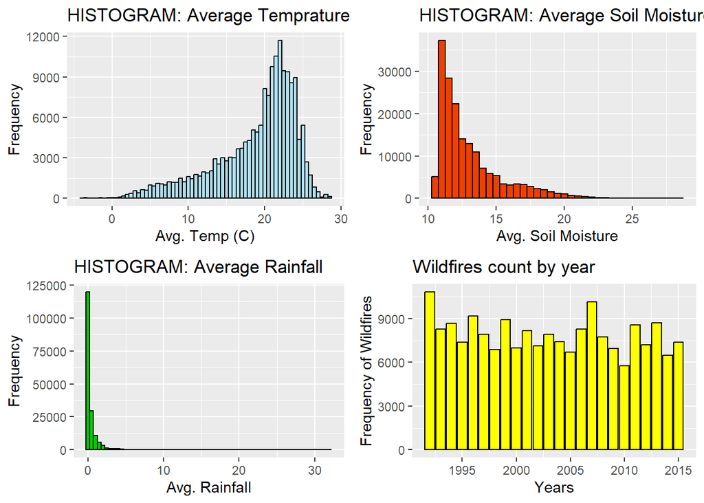

```r
library(ggplot2)
library(gridExtra)
#Average Temperature
TempHist <- ggplot(WildfireData, aes(Avg_Temp))+
  geom_histogram(binwidth = 0.5, bins = 100, col="black", fill="light blue 2") +
  labs(x="Avg. Temp (C)", y="Frequency", title="HISTOGRAM: Average Temprature")


#Average Soil Moisture
SoilHist <- ggplot(WildfireData, aes(Avg_SoilMoisture))+
  geom_histogram(binwidth = 0.5, bins = 100, col="black", fill="orange red 2") +
  labs(x="Avg. Soil Moisture", y="Frequency", title="HISTOGRAM: Average Soil Moisture")

#Average Rainfall
RainHist <- ggplot(WildfireData, aes(Avg_Rainfall))+
  geom_histogram(binwidth = 0.5, bins = 100, col="black", fill="green 3") +
  labs(x="Avg. Rainfall", y="Frequency", title="HISTOGRAM: Average Rainfall")

#Wildfire Count by Year
CountHist <- ggplot(WildfireData, aes(Year))+
  geom_histogram(binwidth = 0.10, bins = 100, col="black", fill="yellow", stat="count") +
  labs(x="Years", y="Frequency of Wildfires", title="Wildfires count by year", )

Histograms <- grid.arrange(TempHist, SoilHist, RainHist, CountHist, ncol=2, nrow=2)
```

```r
ggsave("Histograms.jpg", plot = Histograms)
```

## 4.2 Bar Graphs

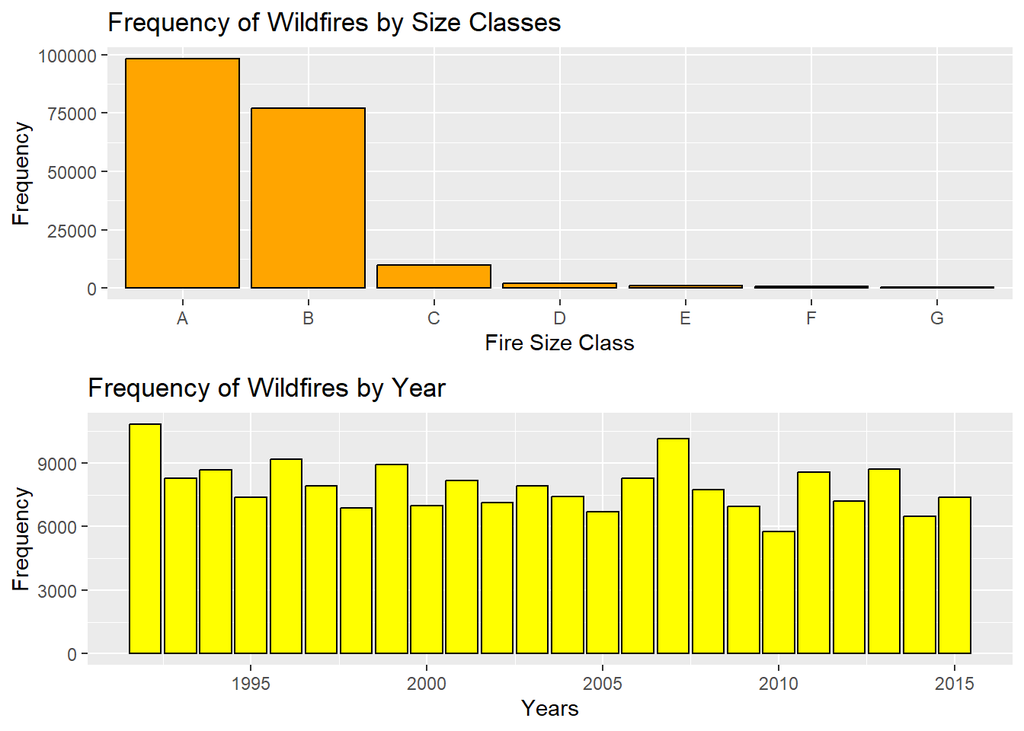

```r
#Fire Size
FireBar <- ggplot(data = WildfireData, aes(x = FIRE_SIZE_CLASS)) +
  geom_bar(col="black", fill="orange")+
  labs(x="Fire Size Class", y="Frequency", title="Frequency of Wildfires by Size Classes")


#Years
YearsBar <- ggplot(data = WildfireData, aes(x = Year)) +
  geom_bar(col="black", fill="yellow")+
  labs(x="Years", y="Frequency", title="Frequency of Wildfires by Year")

#Budget
BudgetBar <- ggplot(data = WildfireData, aes(x = Budget)) +
  geom_bar(col="black", fill="Pink 2")+
  labs(x="Budget", y="Frequency", title="Frequency of Wildfires by Budget")


grid.arrange(FireBar, YearsBar, nrow=2)
```

## 4.3 Pie Charts

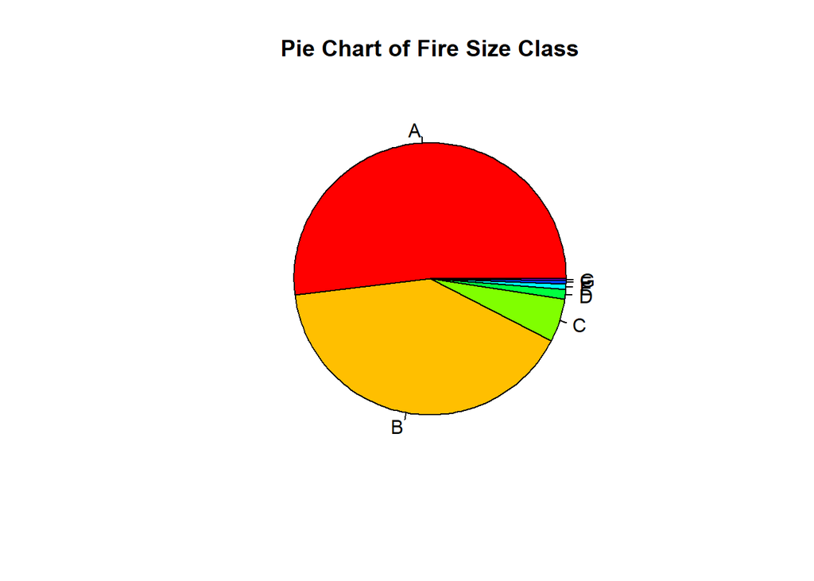

```r
lbls <- c("A", "B", "C", "D", "E", "F", "G", "E")
pie((table(WildfireData$FIRE_SIZE_CLASS)), col=rainbow(length(lbls)), main="Pie Chart of Fire Size Class")
```

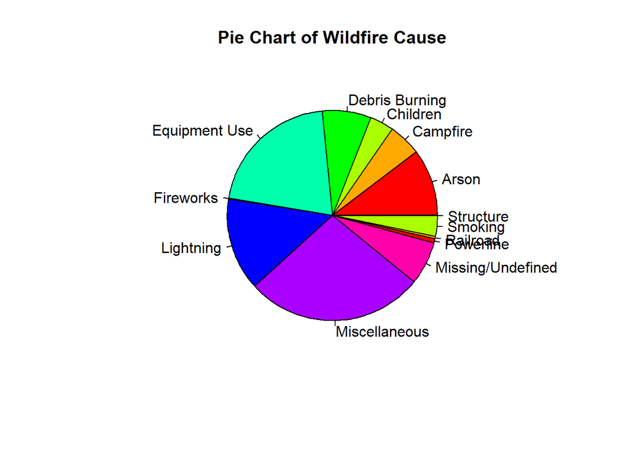

```r
lbls <- c("Lightning", "Eqipment Use", "Smoking", "Campfire", "Debris Burning", "Railroad", "Arson", "Children", "Misc." )
pie((table(WildfireData$STAT_CAUSE_DESCR)), col=rainbow(length(lbls)), main="Pie Chart of Wildfire Cause")
```

## 4.4 Line Charts by Year

```r
library(dplyr)
```

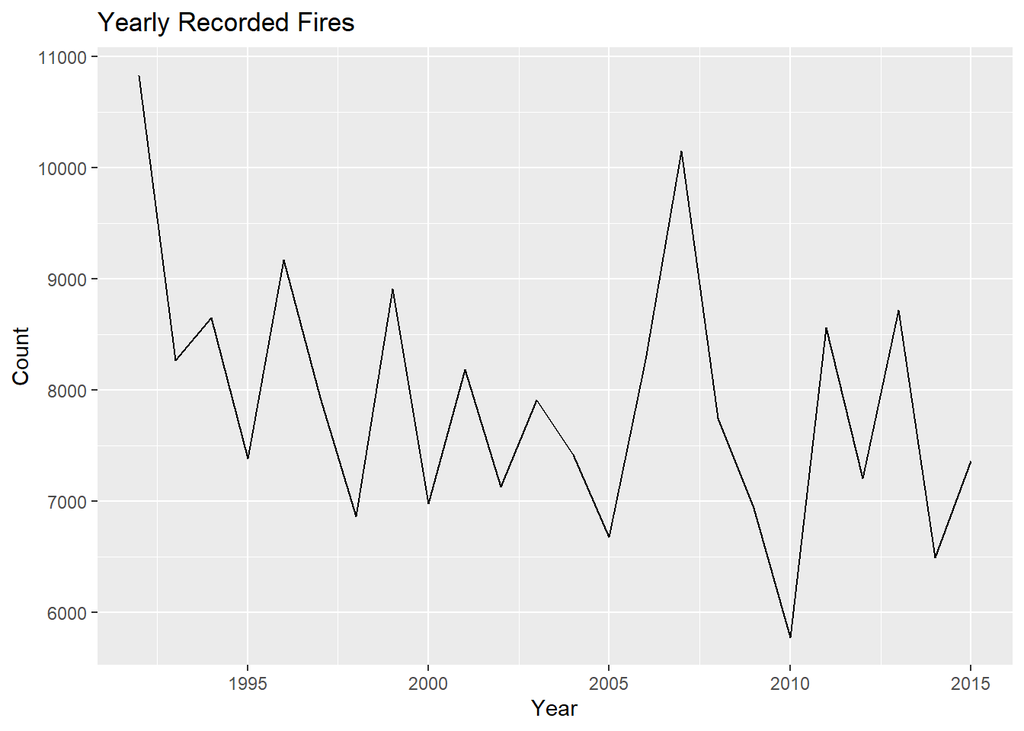

```r
library(ggplot2)
yearly_count <- WildfireData %>% count(Year)
colnames(yearly_count) <- c("Year", "Count")
ggplot(yearly_count, aes(x=Year, y=Count, group=1)) + geom_line() + ggtitle("Yearly Recorded Fires")
```

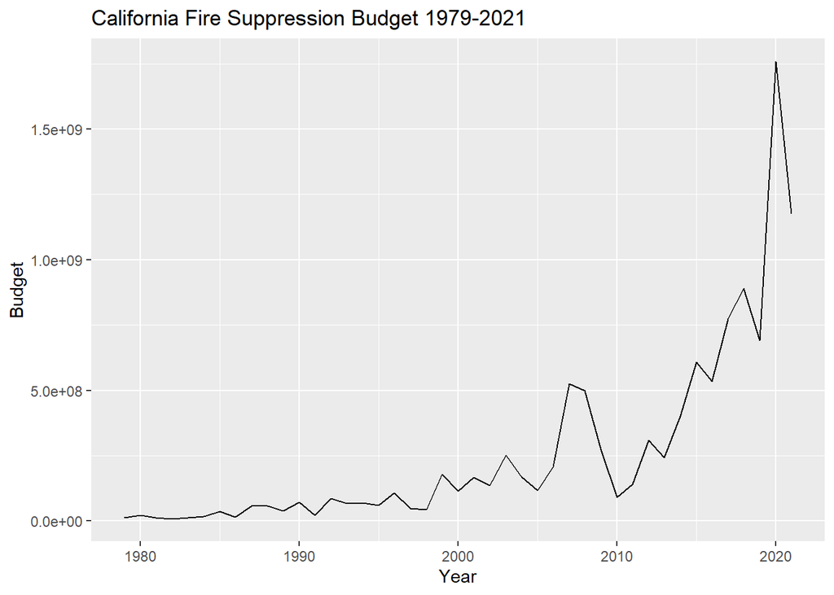

```r
temp=str_remove(fire_budget$Budget,"[$]")
temp=str_remove_all(temp,"[,]")
fire_budget$Budget=as.numeric(temp)
ggplot(fire_budget, aes(x=Year, y=Budget, group=1)) + geom_line() + ggtitle("California Fire Suppression Budget 1979-2021")
```

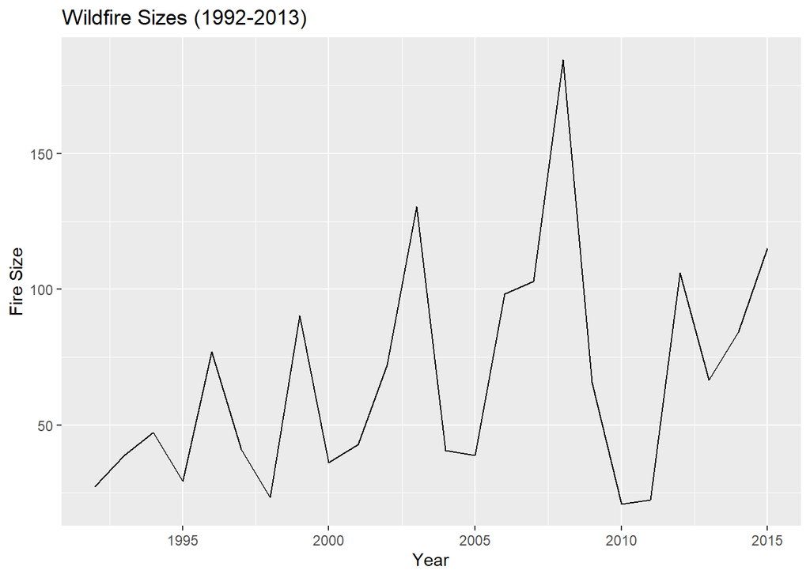

```r
dat <- aggregate(FIRE_SIZE ~ Year, WildfireData, mean)
ggplot(dat, aes(x=Year, y=FIRE_SIZE, group=1)) + geom_line() + ggtitle("Wildfire Sizes (1992-2013)") + ylab("Fire Size")
```

After the EDA, we came away with several thoughts. One of the first metrics we wanted to look into was the California yearly budget for fire suppression. Wildfires have been an issue in this state for many years, so looking at whether or not the funding for wildfire suppression was helping was an important part of our analysis. After visualizing the budget and seeing that it ballooned to over $1 billion over the past couple years, our question about whether or not increased spending helped mitigate wildfires quickly turned into: what was the money going towards? Other than that, our previous questions only got a little more granular. It was clear to see that soil moisture, rainfall, and air temperature didn’t have much effect on the frequency of wildfires from 1992-2015. But we still wanted to know if the conditions during each class and cause of fire differed and by how much.

# Chapter 5: EDA for monthly and annually statistics of wildfire: scatterplot, box-plot and ANOVA

```r
final_fire=read.csv('final_wildfire.csv')
summary_nature=read.csv('summary_nature.csv')
summary_peoplecaused=read.csv('summary_peoplecaused.csv')
colnames(summary_nature)[4]='temperature'
colnames(summary_nature)[5]='soilmoisture'
colnames(summary_nature)[6]='rainfall'
colnames(summary_nature)[7]='nfire'
colnames(summary_peoplecaused)[4]='temperature'
colnames(summary_peoplecaused)[5]='soilmoisture'
colnames(summary_peoplecaused)[6]='rainfall'
colnames(summary_peoplecaused)[7]='nfire'
summary_peoplecaused$Year=as.factor(summary_peoplecaused$Year)

summary_peoplecaused$month=as.factor(summary_peoplecaused$month)
summary_nature$Year=as.factor(summary_nature$Year)

summary_nature$month=as.factor(summary_nature$month)
```

## 5.1: Plots of Annual and Monthly Summary

### 5.1.1: Plotting the year trend

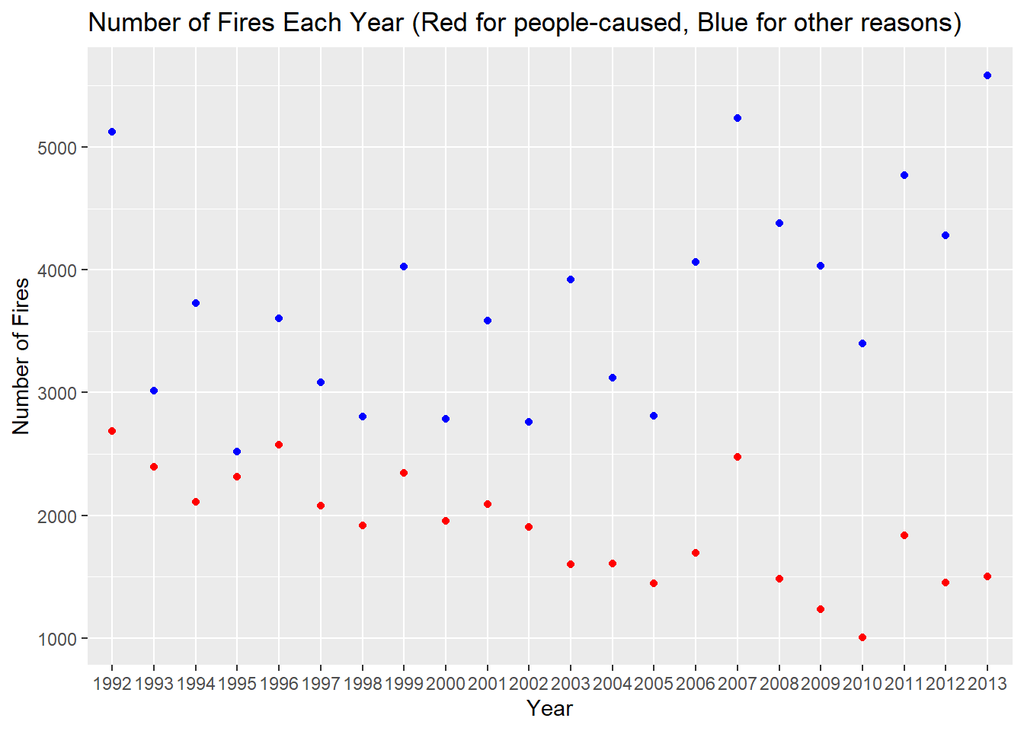

```r
library(ggplot2)

temp_plot=aggregate(nfire~Year,summary_nature,sum)

temp_plot2=aggregate(nfire~Year,summary_peoplecaused,sum)

ggplot() +geom_point(data=temp_plot, aes(x=Year, y=nfire), colour='blue') + geom_point(data=temp_plot2, aes(x=Year, y=nfire),colour='red')+labs(title='Number of Fires Each Year (Red for people-caused, Blue for other reasons)',y='Number of Fires')
```

### 5.1.2: Box-plots of year and month to show trend

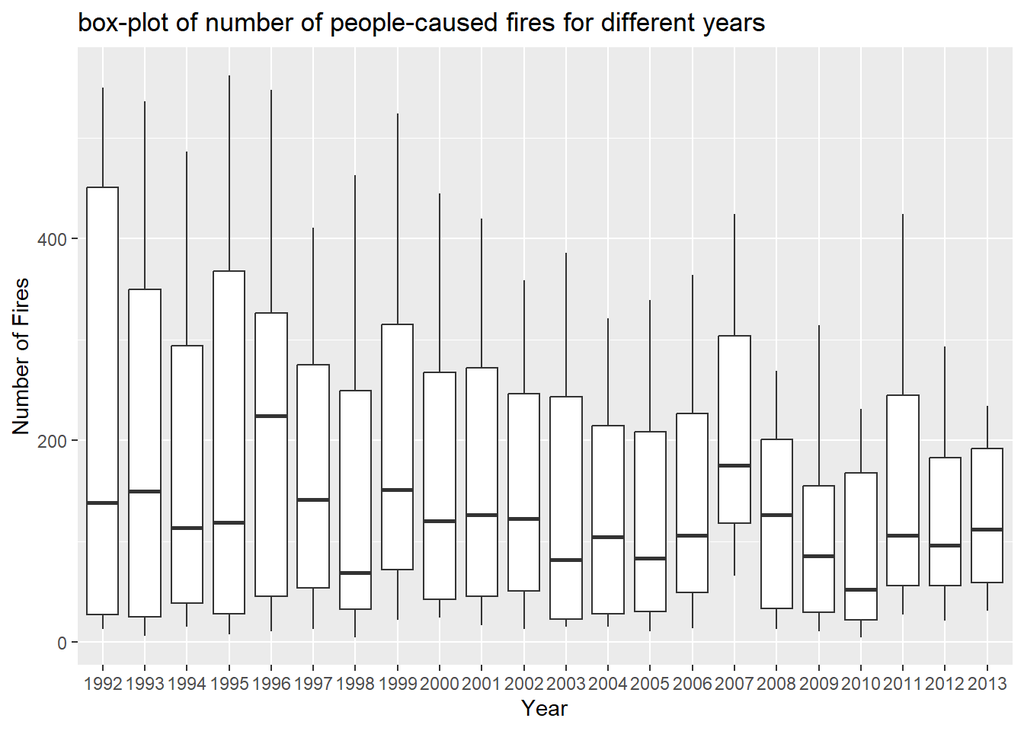

```r
library(ggpubr)
ggplot(summary_peoplecaused, mapping=aes(x=Year,y=nfire)) + geom_boxplot()+ggtitle('box-plot of number of people-caused fires for different years')+ylab('Number of Fires')
```

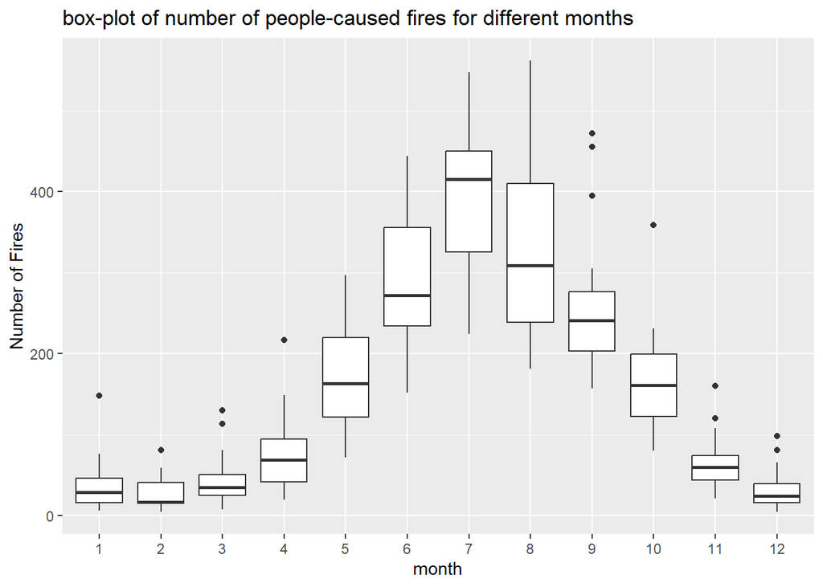

```r
ggplot(summary_peoplecaused, mapping=aes(x=month,y=nfire)) + geom_boxplot()+ggtitle('box-plot of number of people-caused fires for different months')+ylab('Number of Fires')
```

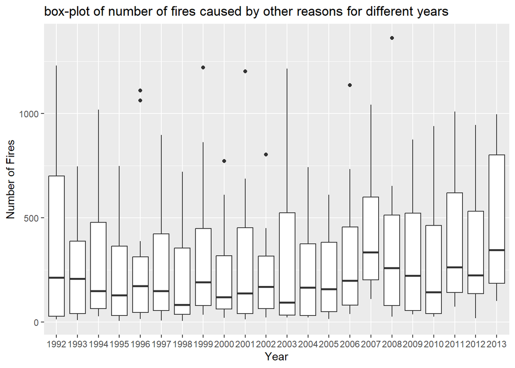

```r
ggplot(summary_nature, mapping=aes(x=Year,y=nfire)) + geom_boxplot()+ggtitle('box-plot of number of fires caused by other reasons for different years')+ylab('Number of Fires')
```

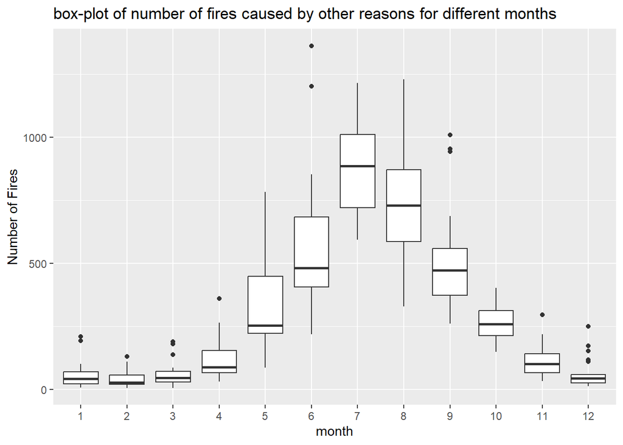

```r
ggplot(summary_nature, mapping=aes(x=month,y=nfire)) + geom_boxplot()+ggtitle('box-plot of number of fires caused by other reasons for different months')+ylab('Number of Fires')
```

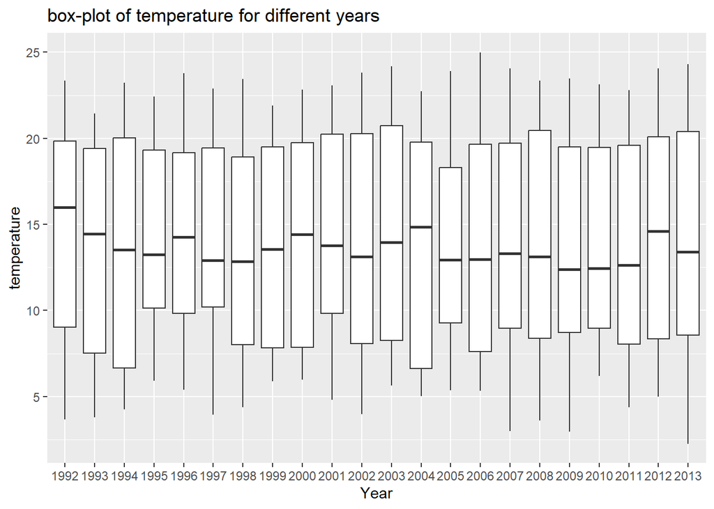

```r
ggplot(summary_peoplecaused, mapping=aes(x=Year,y=temperature)) + geom_boxplot()+ggtitle('box-plot of temperature for different years')+ylab('temperature')
```

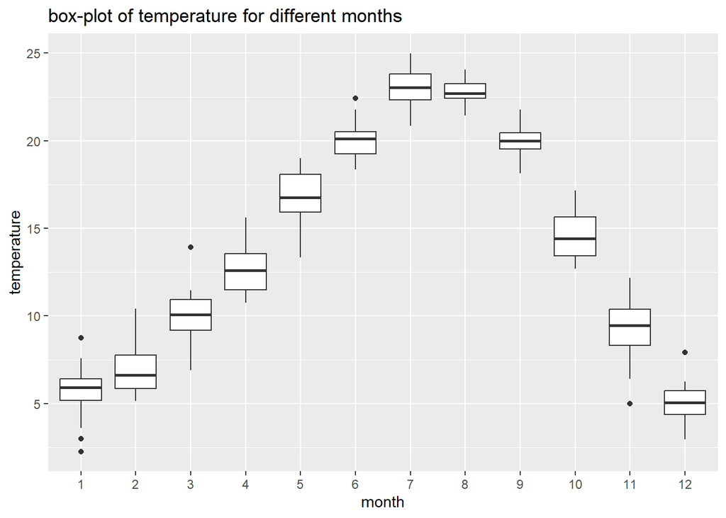

```r
ggplot(summary_peoplecaused, mapping=aes(x=month,y=temperature)) + geom_boxplot()+ggtitle('box-plot of temperature for different months')+ylab('temperature')
```

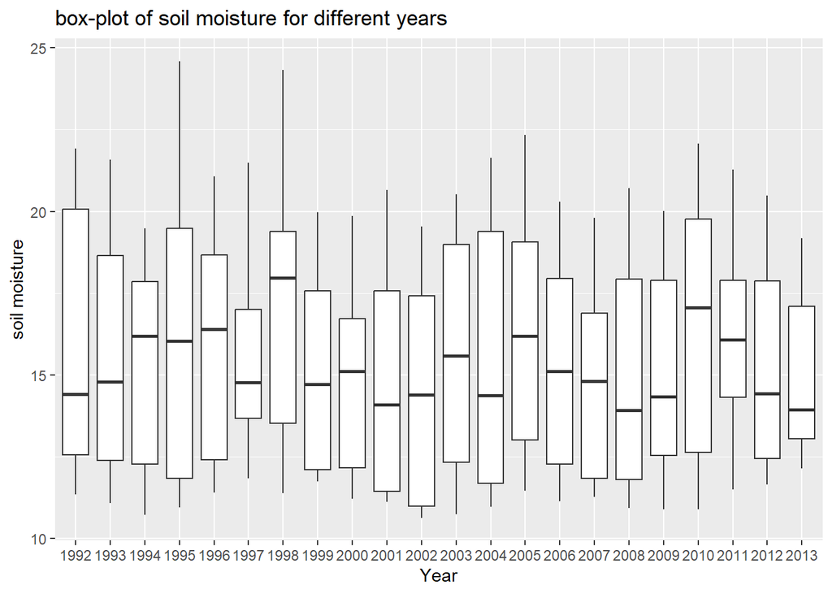

```r
ggplot(summary_nature, mapping=aes(x=Year,y=soilmoisture)) + geom_boxplot()+ggtitle('box-plot of soil moisture for different years')+ylab('soil moisture')
```

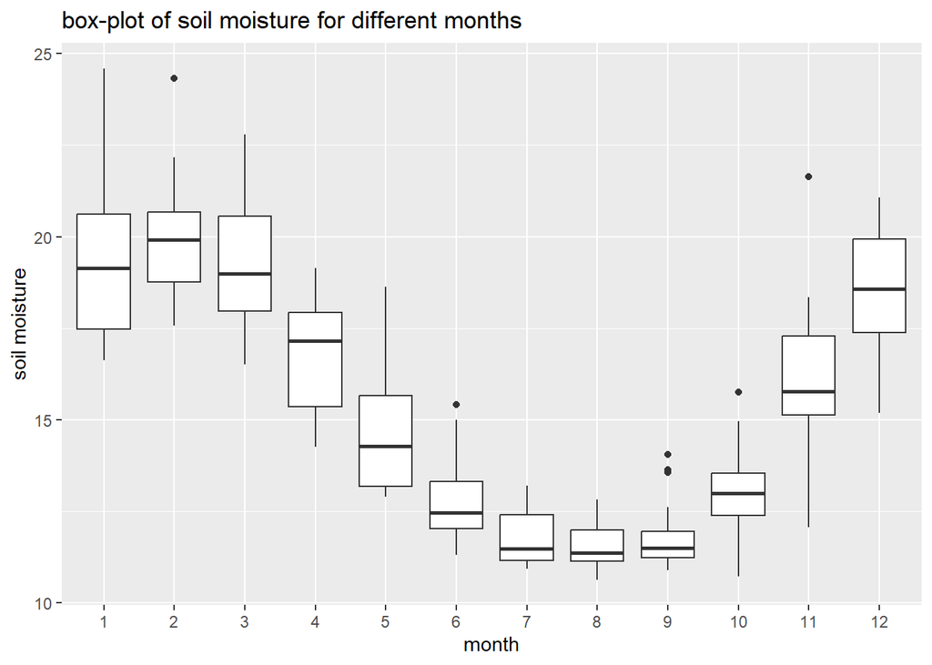

```r
ggplot(summary_nature, mapping=aes(x=month,y=soilmoisture)) + geom_boxplot()+ggtitle('box-plot of soil moisture for different months')+ylab('soil moisture')
```

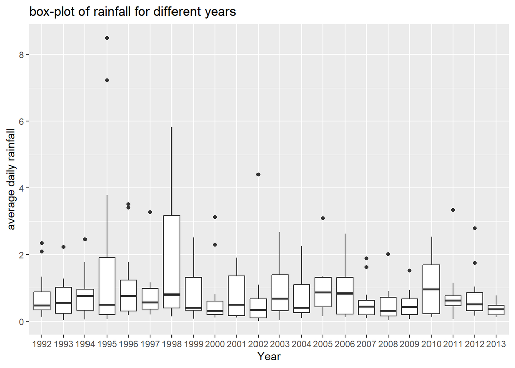

```r
ggplot(summary_nature, mapping=aes(x=Year,y=rainfall)) + geom_boxplot()+ggtitle('box-plot of rainfall for different years')+ylab('average daily rainfall')
```

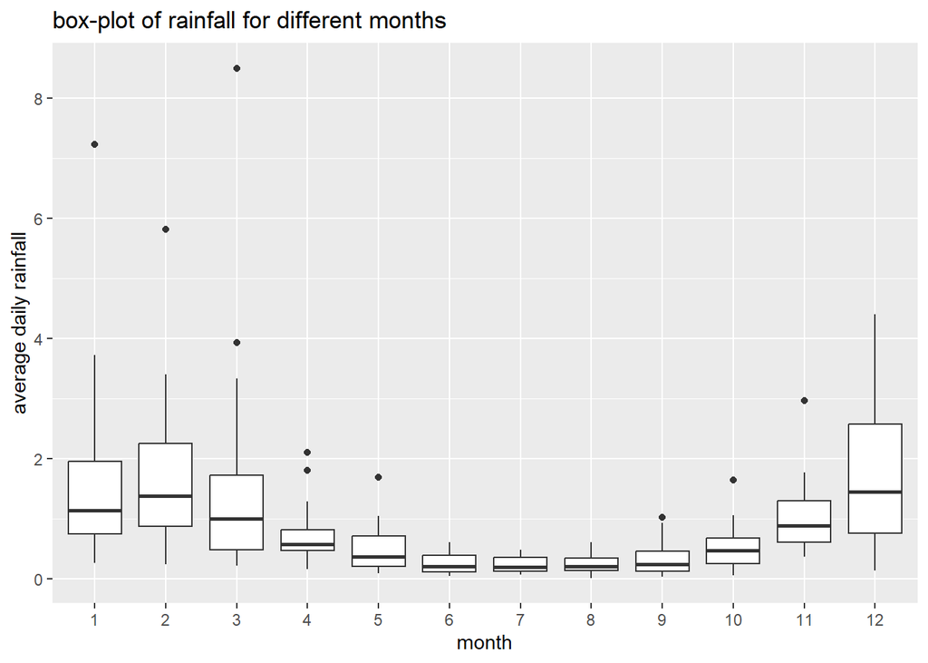

```r
ggplot(summary_nature, mapping=aes(x=month,y=rainfall)) + geom_boxplot()+ggtitle('box-plot of rainfall for different months')+ylab('average daily rainfall')
```

The result of box-plot suppose the annually summary for all variables(fires number, temperature rainfall and moisture) are consistent and monthly summary for all variables are different. It supposes that we could need to take anova test for the mean with those categories.

## 5.2: Anova test on the year and month statistics

```r
'test wildfire cases caused by people of different years'
```

```
## [1] "test wildfire cases caused by people of different years"
```

```r
summary(aov(nfire~Year,summary_peoplecaused))
```

```
##              Df  Sum Sq Mean Sq F value Pr(>F)
## Year         21  360393   17162   0.849  0.657
## Residuals   242 4892242   20216
```

```r
'test wildfire cases caused by people of different months'
```

```
## [1] "test wildfire cases caused by people of different months"
```

```r
summary(aov(nfire~month,summary_peoplecaused))
```

```
##              Df  Sum Sq Mean Sq F value Pr(>F)
## month        11 4167871  378897   88.02 <2e-16 ***
## Residuals   252 1084764    4305
## ---
## Signif. codes:  0 '***' 0.001 '**' 0.01 '*' 0.05 '.' 0.1 ' ' 1
```

```r
'test wildfire cases by natrual reasons of different years'
```

```
## [1] "test wildfire cases by natrual reasons of different years"
```

```r
summary(aov(nfire~Year,summary_nature))
```

```
##              Df   Sum Sq Mean Sq F value Pr(>F)
## Year         21  1352086   64385   0.608  0.911
## Residuals   242 25626302  105894
```

```r
'test wildfire cases by natrual reasons of different months'
```

```
## [1] "test wildfire cases by natrual reasons of different months"
```

```r
summary(aov(nfire~month,summary_nature))
```

```
##              Df   Sum Sq Mean Sq F value Pr(>F)
## month        11 21164133 1924012   83.39 <2e-16 ***
## Residuals   252  5814256   23072
## ---
## Signif. codes:  0 '***' 0.001 '**' 0.01 '*' 0.05 '.' 0.1 ' ' 1
```

```r
'test average temperature in a month of different years'
```

```
## [1] "test average temperature in a month of different years"
```

```r
summary(aov(temperature~Year,summary_peoplecaused))
```

```
##              Df Sum Sq Mean Sq F value Pr(>F)
## Year         21     31    1.47   0.033      1
## Residuals   242  10855   44.85
```

```r
'test average temperature in a month of different months'
```

```
## [1] "test average temperature in a month of different months"
```

```r
summary(aov(temperature~month,summary_peoplecaused))
```

```
##              Df Sum Sq Mean Sq F value Pr(>F)
## month        11  10458   950.7   560.1 <2e-16 ***
## Residuals   252    428     1.7
## ---
## Signif. codes:  0 '***' 0.001 '**' 0.01 '*' 0.05 '.' 0.1 ' ' 1
```

```r
'test average soil moisture in a month of different years'
```

```
## [1] "test average soil moisture in a month of different years"
```

```r
summary(aov(soilmoisture~Year,summary_nature))
```

```
##              Df Sum Sq Mean Sq F value Pr(>F)
## Year         21  129.9   6.185   0.491  0.972
## Residuals   242 3048.5  12.597
```

```r
'test average soil moisture in a month of different months'
```

```
## [1] "test average soil moisture in a month of different months"
```

```r
summary(aov(soilmoisture~month,summary_nature))
```

```
##              Df Sum Sq Mean Sq F value Pr(>F)
## month        11 2616.9  237.90   106.8 <2e-16 ***
## Residuals   252  561.5    2.23
## ---
## Signif. codes:  0 '***' 0.001 '**' 0.01 '*' 0.05 '.' 0.1 ' ' 1
```

```r
'test average rainfall in a month of different years'
```

```
## [1] "test average rainfall in a month of different years"
```

```r
summary(aov(rainfall~Year,summary_nature))
```

```
##              Df Sum Sq Mean Sq F value Pr(>F)
## Year         21  34.08   1.623   1.458 0.0931 .
## Residuals   242 269.34   1.113
## ---
## Signif. codes:  0 '***' 0.001 '**' 0.01 '*' 0.05 '.' 0.1 ' ' 1
```

```r
'test average rainfall in a month of different months'
```

```
## [1] "test average rainfall in a month of different months"
```

```r
summary(aov(rainfall~month,summary_nature))
```

```
##              Df Sum Sq Mean Sq F value   Pr(>F)
## month        11  95.17   8.652   10.47 8.85e-16 ***
## Residuals   252 208.25   0.826
## ---
## Signif. codes:  0 '***' 0.001 '**' 0.01 '*' 0.05 '.' 0.1 ' ' 1
```

We have the null hypothesis that the mean of particular varible with different categories is same and the alternative hypothesis suppose that mean of particular varible with different categories is different The anova test give the results For all of variables with annually categories, we failed to reject the null hypothesis For all of variables with monthly categories, we reject the null hypothesis.

The result suppose the variables(fires number, temperature, rainfall and moisture) are consistent with year and have great difference with months. Since, we do not find statistical significance on the difference on wildfire cases of different years, the EDA results also change the SMART question to that the temperature can increase the wildfire cases or not.

# Chapter 6: Hypothesis Testing

To investigate how the conditions differed during each class and cause of fire, we used Hypothesis testing- specifically t-tests. We first had to split the wildfires up into different groups for the first hypothesis test. We looked to compare different classes of wildfires and how different conditions may have been. Classes A-G describe the size of the fire with Class A being the smallest and Class G being the largest.

```r
classA <- WildfireData[WildfireData$FIRE_SIZE_CLASS == 'A',]
classB <- WildfireData[WildfireData$FIRE_SIZE_CLASS == 'B',]
classC <- WildfireData[WildfireData$FIRE_SIZE_CLASS == 'C',]
classD <- WildfireData[WildfireData$FIRE_SIZE_CLASS == 'D',]
classE <- WildfireData[WildfireData$FIRE_SIZE_CLASS == 'E',]
classF <- WildfireData[WildfireData$FIRE_SIZE_CLASS == 'F',]
classG <- WildfireData[WildfireData$FIRE_SIZE_CLASS == 'G',]
```

When comparing the conditions during the smallest wildfires to the largest wildfires, it appears that air temperature was lower, soil moisture was higher, and rainfall was higher during less intense wildfires.

```r
t.test(classA$tair_day_livneh_vic, classG$tair_day_livneh_vic, var.equal = TRUE)
```

```
##
##  Two Sample t-test
##
## data:  classA$tair_day_livneh_vic and classG$tair_day_livneh_vic
## t = -8.7583, df = 89797, p-value < 2.2e-16
## alternative hypothesis: true difference in means is not equal to 0
## 95 percent confidence interval:
##  -3.195132 -2.026586
## sample estimates:
## mean of x mean of y
##  18.70072  21.31158
```

```r
t.test(classA$soilmoist1_day_livneh_vic, classG$soilmoist1_day_livneh_vic, var.equal = TRUE)
```

```
##
##  Two Sample t-test
##
## data:  classA$soilmoist1_day_livneh_vic and classG$soilmoist1_day_livneh_vic
## t = 8.175, df = 89797, p-value = 2.998e-16
## alternative hypothesis: true difference in means is not equal to 0
## 95 percent confidence interval:
##  0.8259187 1.3468515
## sample estimates:
## mean of x mean of y
##  13.08929  12.00291
```

```r
t.test(classA$rainfall_day_livneh_vic, classG$rainfall_day_livneh_vic, var.equal = TRUE)
```

```
##
##  Two Sample t-test
##
## data:  classA$rainfall_day_livneh_vic and classG$rainfall_day_livneh_vic
## t = 4.4724, df = 89797, p-value = 7.744e-06
## alternative hypothesis: true difference in means is not equal to 0
## 95 percent confidence interval:
##  0.1484135 0.3799739
## sample estimates:
## mean of x mean of y
## 0.4636929 0.1994992
```

```r
code1 <- WildfireData[WildfireData$STAT_CAUSE_CODE == 1,]
code2 <- WildfireData[WildfireData$STAT_CAUSE_CODE == 2,]
code7 <- WildfireData[WildfireData$STAT_CAUSE_CODE == 7,]
```

Now, we will compare different groups of wildfires- categorized by their causes.

Code 1: Lightning  
Code 2: Equipment Use  
Code 7: Arson

When looking at the wildfires caused by Lightning versus those caused by Equipment Use, average temperature, soil moisture, and rainfall in CA were significantly different. In particular, during Lighting-caused wildfires, air temperature was higher, soil moisture was lower, and rainfall was higher.

```r
t.test(code1$tair_day_livneh_vic, code2$tair_day_livneh_vic, var.equal=TRUE)
```

```
##
##  Two Sample t-test
##
## data:  code1$tair_day_livneh_vic and code2$tair_day_livneh_vic
## t = 85.583, df = 62967, p-value < 2.2e-16
## alternative hypothesis: true difference in means is not equal to 0
## 95 percent confidence interval:
##  2.936384 3.074032
## sample estimates:
## mean of x mean of y
##  22.10035  19.09514
```

```r
t.test(code1$soilmoist1_day_livneh_vic, code2$soilmoist1_day_livneh_vic, var.equal=TRUE)
```

```
##
##  Two Sample t-test
##
## data:  code1$soilmoist1_day_livneh_vic and code2$soilmoist1_day_livneh_vic
## t = -38.009, df = 62967, p-value < 2.2e-16
## alternative hypothesis: true difference in means is not equal to 0
## 95 percent confidence interval:
##  -0.6264540 -0.5650133
## sample estimates:
## mean of x mean of y
##  12.19398  12.78972
```

```r
t.test(code1$rainfall_day_livneh_vic, code2$rainfall_day_livneh_vic, var.equal=TRUE)
```

```
##
##  Two Sample t-test
##
## data:  code1$rainfall_day_livneh_vic and code2$rainfall_day_livneh_vic
## t = 30.919, df = 62967, p-value < 2.2e-16
## alternative hypothesis: true difference in means is not equal to 0
## 95 percent confidence interval:
##  0.2152689 0.2444081
## sample estimates:
## mean of x mean of y
## 0.5694914 0.3396529
```

When comparing the wildfires caused by Lightning versus those caused by Arson, it appears that the air temperature, soil moisture, and average rainfall in CA were significantly different. In particular, during lightning-caused wildfires, air temperature was higher, soil moisture was lower, and average rainfall was higher.

```r
t.test(code1$tair_day_livneh_vic, code7$tair_day_livneh_vic, var.equal=TRUE)
```

```
##
##  Two Sample t-test
##
## data:  code1$tair_day_livneh_vic and code7$tair_day_livneh_vic
## t = 82.448, df = 43091, p-value < 2.2e-16
## alternative hypothesis: true difference in means is not equal to 0
## 95 percent confidence interval:
##  3.208857 3.365139
## sample estimates:
## mean of x mean of y
##  22.10035  18.81335
```

```r
t.test(code1$soilmoist1_day_livneh_vic, code7$soilmoist1_day_livneh_vic, var.equal=TRUE)
```

```
##
##  Two Sample t-test
##
## data:  code1$soilmoist1_day_livneh_vic and code7$soilmoist1_day_livneh_vic
## t = -39.235, df = 43091, p-value < 2.2e-16
## alternative hypothesis: true difference in means is not equal to 0
## 95 percent confidence interval:
##  -0.7279409 -0.6586716
## sample estimates:
## mean of x mean of y
##  12.19398  12.88729
```

```r
t.test(code1$rainfall_day_livneh_vic, code7$rainfall_day_livneh_vic, var.equal=TRUE)
```

```
##
##  Two Sample t-test
##
## data:  code1$rainfall_day_livneh_vic and code7$rainfall_day_livneh_vic
## t = 26.917, df = 43091, p-value < 2.2e-16
## alternative hypothesis: true difference in means is not equal to 0
## 95 percent confidence interval:
##  0.2019315 0.2336487
## sample estimates:
## mean of x mean of y
## 0.5694914 0.3517013
```

When looking at conditions during arson-caused wildfires versus equipment use-caused wildfires, it appears that air temperature and soil moisture were significantly different. In particular, during arson-caused fires, air temperature was lower and soil moisture was higher.

```r
t.test(code7$tair_day_livneh_vic, code2$tair_day_livneh_vic, var.equal=TRUE)
```

```
##
##  Two Sample t-test
##
## data:  code7$tair_day_livneh_vic and code2$tair_day_livneh_vic
## t = -6.3054, df = 56768, p-value = 2.895e-10
## alternative hypothesis: true difference in means is not equal to 0
## 95 percent confidence interval:
##  -0.3693827 -0.1941972
## sample estimates:
## mean of x mean of y
##  18.81335  19.09514
```

```r
t.test(code7$soilmoist1_day_livneh_vic, code2$soilmoist1_day_livneh_vic, var.equal=TRUE)
```

```
##
##  Two Sample t-test
##
## data:  code7$soilmoist1_day_livneh_vic and code2$soilmoist1_day_livneh_vic
## t = 4.7886, df = 56768, p-value = 1.684e-06
## alternative hypothesis: true difference in means is not equal to 0
## 95 percent confidence interval:
##  0.05763517 0.13750998
## sample estimates:
## mean of x mean of y
##  12.88729  12.78972
```

```r
t.test(code7$rainfall_day_livneh_vic, code2$rainfall_day_livneh_vic, var.equal=TRUE)
```

```
##
##  Two Sample t-test
##
## data:  code7$rainfall_day_livneh_vic and code2$rainfall_day_livneh_vic
## t = 1.3998, df = 56768, p-value = 0.1616
## alternative hypothesis: true difference in means is not equal to 0
## 95 percent confidence interval:
##  -0.004821767  0.028918604
## sample estimates:
## mean of x mean of y
## 0.3517013 0.3396529
```

# Chapter 7: Correlation and Liner Regression model

## 7.1: Correlation Matrix

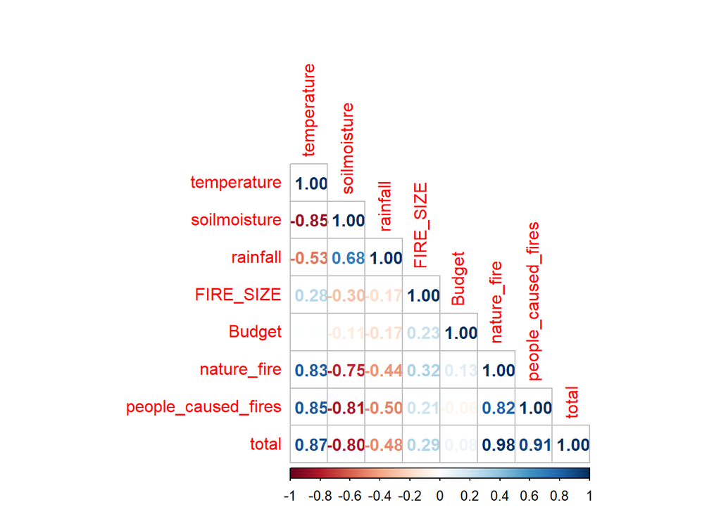

```r
temp=str_remove(summary_nature$Budget,"[$]")
temp=str_remove_all(temp,"[,]")
summary_nature$Budget=as.numeric(temp)
temp=str_remove(summary_peoplecaused$Budget,"[$]")
temp=str_remove_all(temp,"[,]")
summary_peoplecaused$Budget=as.numeric(temp)
cor_nature=cor(summary_nature[c(4:9)])

library(corrplot)
cor_people=cor(summary_peoplecaused[c(4:9)])



colnames(summary_nature)[7]='nature_fire'
summary_nature$people_caused_fires=summary_peoplecaused$n
summary_nature$total=summary_nature$nature_fire+summary_peoplecaused$n
cor_total=cor(summary_nature[c(4,5,6,8,9,7,10,11)])


corrplot(cor_total,method='number',type = 'lower', diag = TRUE)
```

From the EDA, we try to evaluate the wildfires in two cases: people-caused and other reason(usually natrual reasons). The result suppose that fires number for both type(man-caused and other) has strong correlation with temperature and moisture. This implies that we could make model to evaluate the influence of nature factors to answer SMART question.

## 7.2 Smart Question: Did the higher temperature increase the cases of wildfire in a month?

```r
model1=lm(log(total)~temperature,data=summary_nature)
summary(model1)
```

```
##
## Call:
## lm(formula = log(total) ~ temperature, data = summary_nature)
##
## Residuals:
##     Min      1Q  Median      3Q     Max
## -2.1440 -0.2903  0.0246  0.3383  2.1626
##
## Coefficients:
##             Estimate Std. Error t value Pr(>|t|)
## (Intercept) 3.214663   0.086869   37.01   <2e-16 ***
## temperature 0.168488   0.005676   29.68   <2e-16 ***
## ---
## Signif. codes:  0 '***' 0.001 '**' 0.01 '*' 0.05 '.' 0.1 ' ' 1
##
## Residual standard error: 0.5922 on 262 degrees of freedom
## Multiple R-squared:  0.7708, Adjusted R-squared:  0.7699
## F-statistic: 881.1 on 1 and 262 DF,  p-value: < 2.2e-16
```

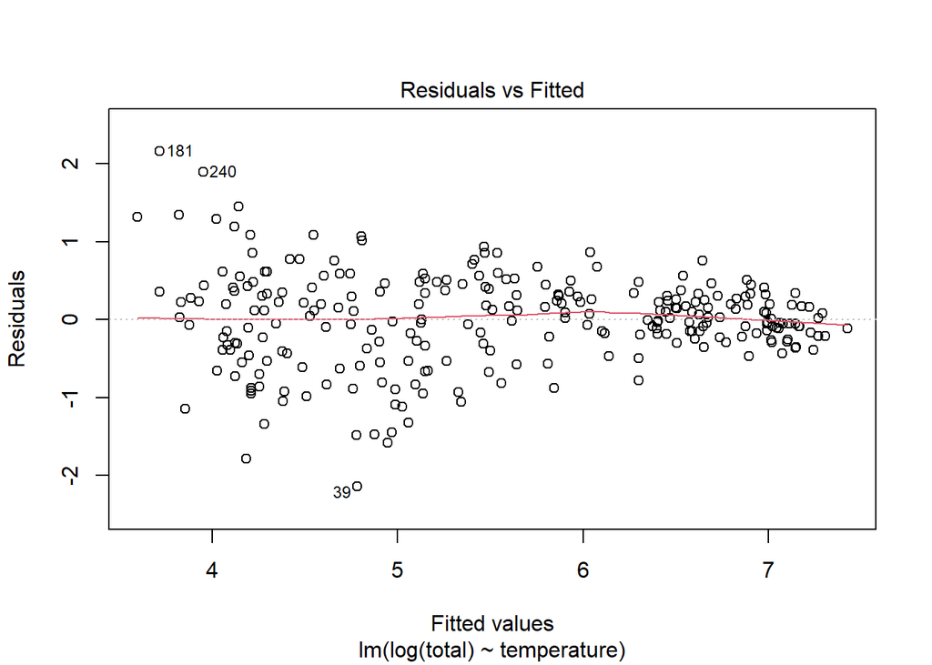

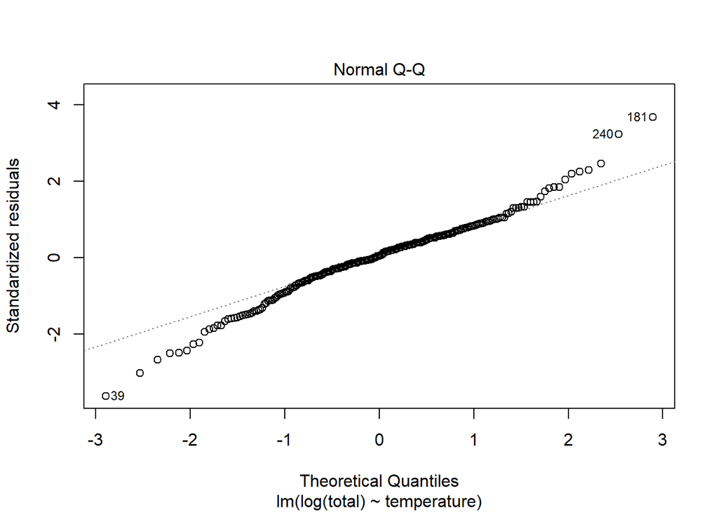

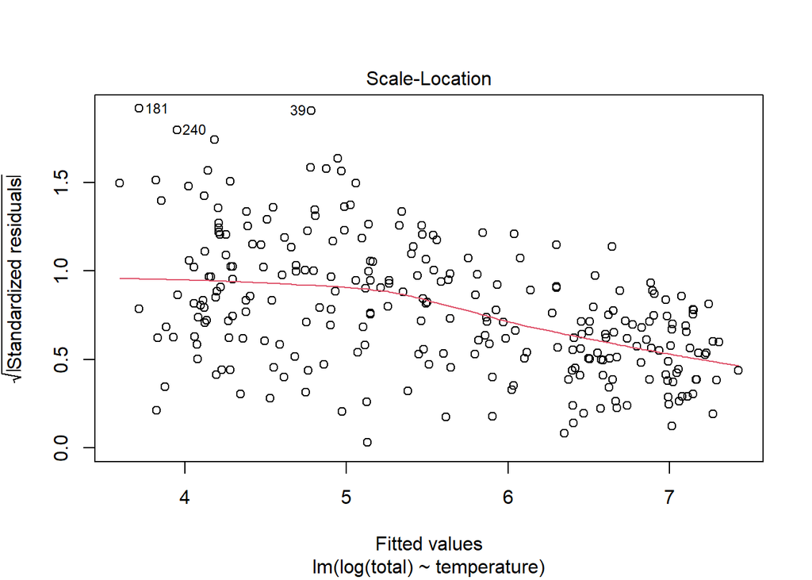

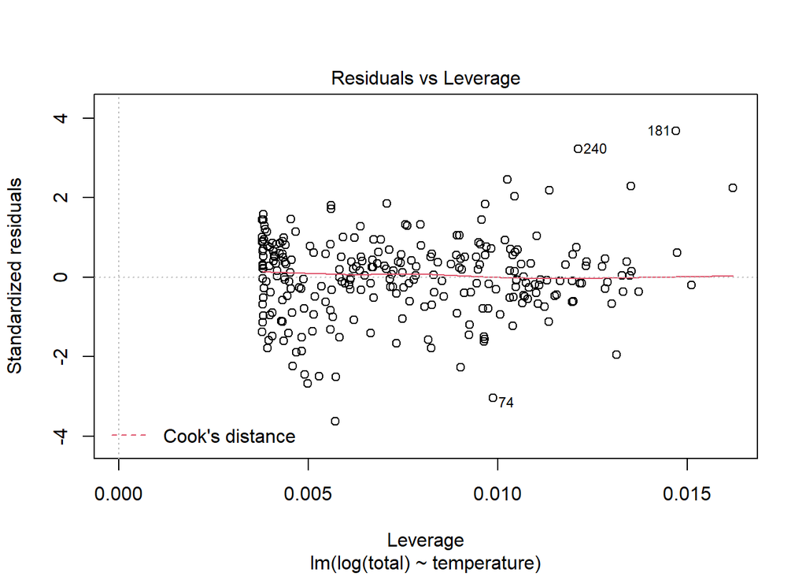

```r
plot(model1)
```

```r
anova(model1)
```

```
## Analysis of Variance Table
##
## Response: log(total)
##              Df  Sum Sq Mean Sq F value    Pr(>F)
## temperature   1 309.024 309.024  881.07 < 2.2e-16 ***
## Residuals   262  91.893   0.351
## ---
## Signif. codes:  0 '***' 0.001 '**' 0.01 '*' 0.05 '.' 0.1 ' ' 1
```

## 7.3 Smart Question: Did high precipitation decreases the cases of wildfire in a month?

```r
model2=lm(total~rainfall,data=summary_nature)
summary(model2)
```

```
##
## Call:
## lm(formula = total ~ rainfall, data = summary_nature)
##
## Residuals:
##    Min     1Q Median     3Q    Max
## -534.5 -300.8 -118.8  223.9 1220.9
##
## Coefficients:
##             Estimate Std. Error t value Pr(>|t|)
## (Intercept)   644.66      31.05  20.760   <2e-16 ***
## rainfall     -197.46      22.39  -8.818   <2e-16 ***
## ---
## Signif. codes:  0 '***' 0.001 '**' 0.01 '*' 0.05 '.' 0.1 ' ' 1
##
## Residual standard error: 390.1 on 262 degrees of freedom
## Multiple R-squared:  0.2288, Adjusted R-squared:  0.2259
## F-statistic: 77.75 on 1 and 262 DF,  p-value: < 2.2e-16
```

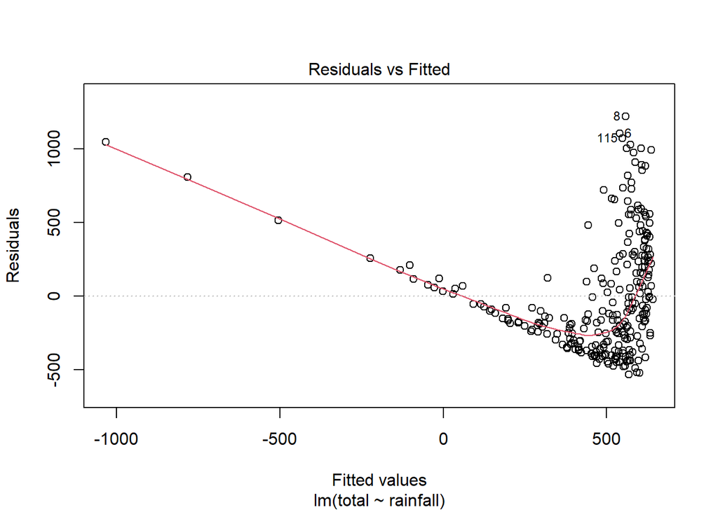

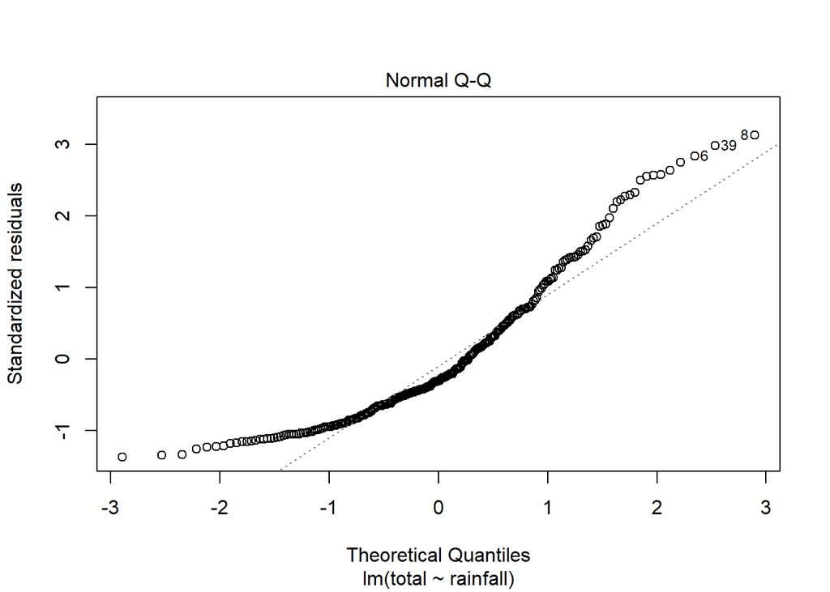

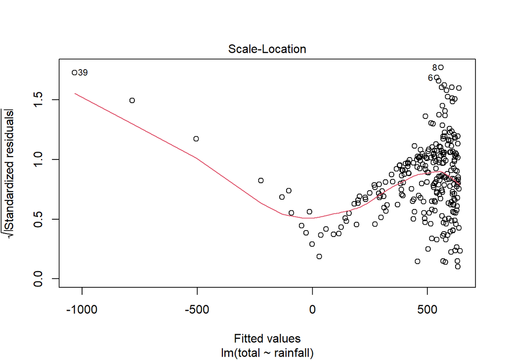

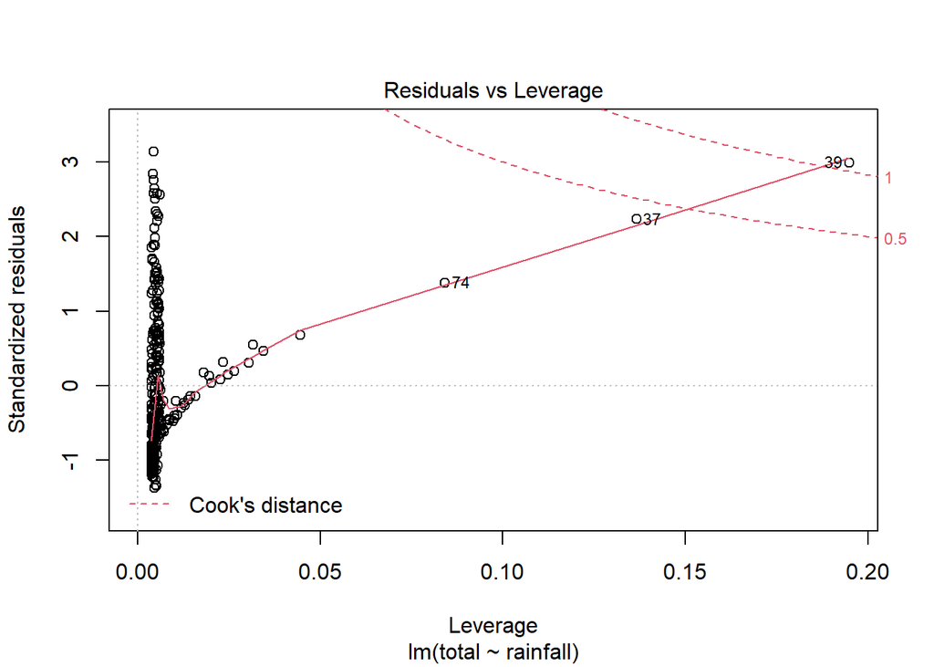

```r
plot(model2)
```

```r
anova(model2)
```

```
## Analysis of Variance Table
##
## Response: total
##            Df   Sum Sq  Mean Sq F value    Pr(>F)
## rainfall    1 11830030 11830030  77.749 < 2.2e-16 ***
## Residuals 262 39865035   152157
## ---
## Signif. codes:  0 '***' 0.001 '**' 0.01 '*' 0.05 '.' 0.1 ' ' 1
```

The model result supposes the linear model with 0.23 r-squared and a 0 p-value of F-test, it supposes the coefficient for rainfall is not 0, The estimated coefficient is -197. From the model we can answer that the high precipitation could decrease the number of wildfire cases; however, it only can explain the 23 percentage of variation on wildfire cases.

## 7.4 Smart Question: Did low soilmoisture level increases the cases of wildfire in a month?

```r
model3=lm(log(total)~soilmoisture,data=summary_nature)
summary(model3)
```

```
##
## Call:
## lm(formula = log(total) ~ soilmoisture, data = summary_nature)
##
## Residuals:
##      Min       1Q   Median       3Q      Max
## -1.23250 -0.28142 -0.01689  0.33147  1.06163
##
## Coefficients:
##               Estimate Std. Error t value Pr(>|t|)
## (Intercept)  10.679760   0.125615   85.02   <2e-16 ***
## soilmoisture -0.331202   0.007922  -41.81   <2e-16 ***
## ---
## Signif. codes:  0 '***' 0.001 '**' 0.01 '*' 0.05 '.' 0.1 ' ' 1
##
## Residual standard error: 0.4466 on 262 degrees of freedom
## Multiple R-squared:  0.8697, Adjusted R-squared:  0.8692
## F-statistic:  1748 on 1 and 262 DF,  p-value: < 2.2e-16
```

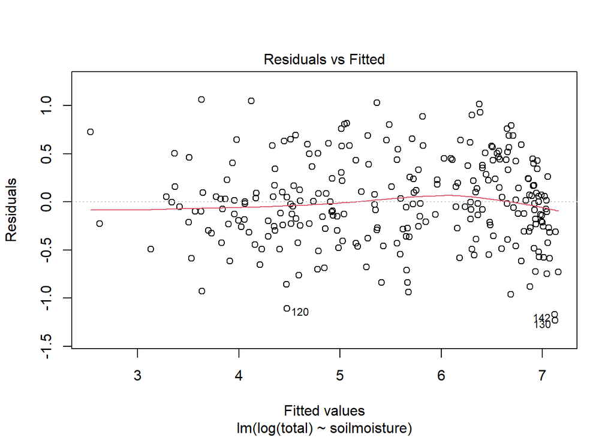

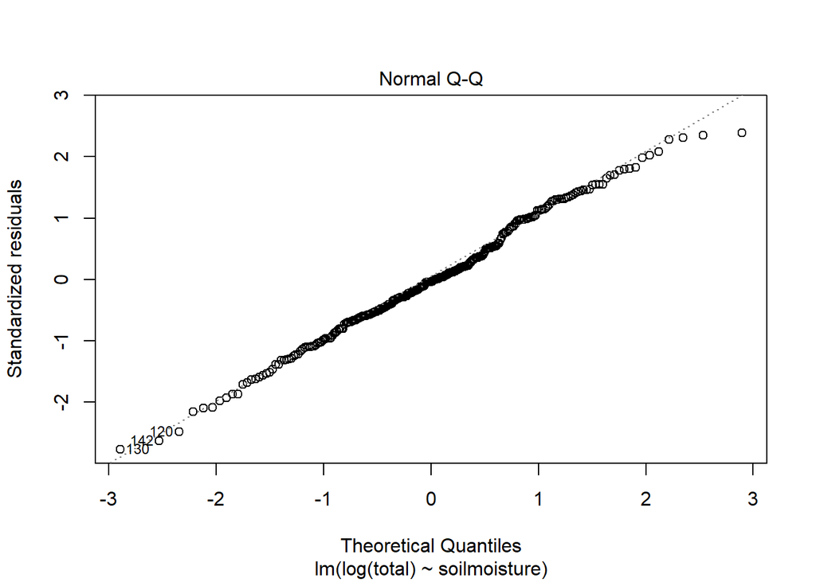

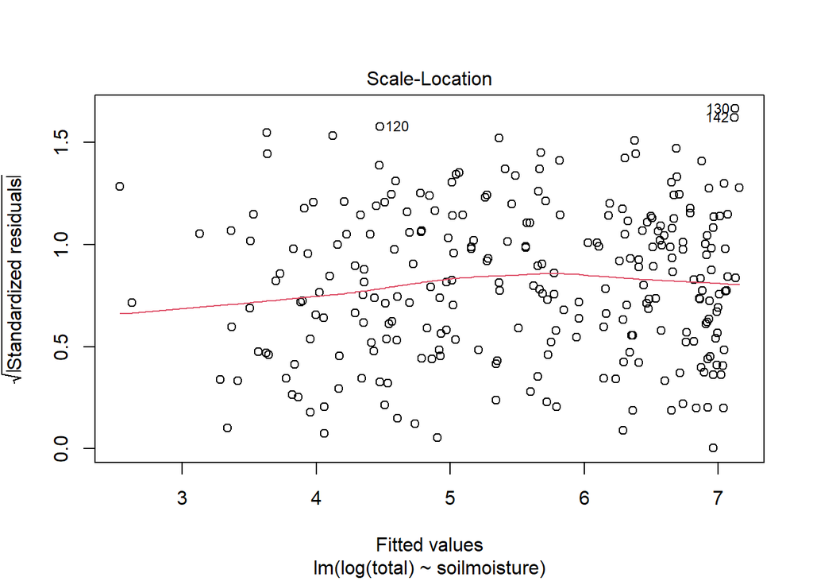

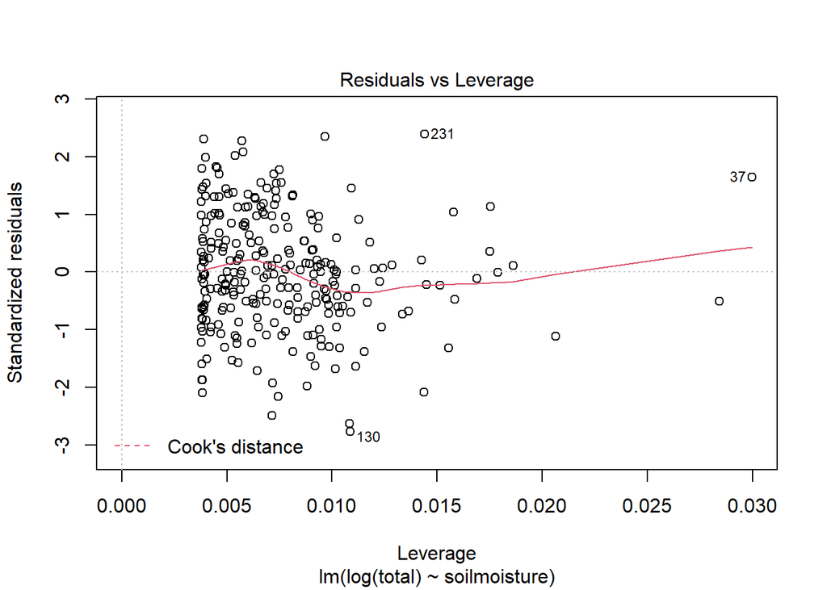

```r
plot(model3)
```

```r
anova(model3)
```

```
## Analysis of Variance Table
##
## Response: log(total)
##               Df Sum Sq Mean Sq F value    Pr(>F)
## soilmoisture   1 348.66  348.66    1748 < 2.2e-16 ***
## Residuals    262  52.26    0.20
## ---
## Signif. codes:  0 '***' 0.001 '**' 0.01 '*' 0.05 '.' 0.1 ' ' 1
```

## 7.5 Smart Question: Did lower expenditure on fire supression in California result in larger wildfires?

```r
model4=lm(FIRE_SIZE~Budget,data=summary_nature)
summary(model4)
```

```
##
## Call:
## lm(formula = FIRE_SIZE ~ Budget, data = summary_nature)
##
## Residuals:
##     Min      1Q  Median      3Q     Max
## -110.06  -38.53  -22.26    0.41  807.54
##
## Coefficients:
##              Estimate Std. Error t value Pr(>|t|)
## (Intercept) 1.153e+01  1.100e+01   1.047 0.295846
## Budget      1.891e-07  5.023e-08   3.764 0.000206 ***
## ---
## Signif. codes:  0 '***' 0.001 '**' 0.01 '*' 0.05 '.' 0.1 ' ' 1
##
## Residual standard error: 105.2 on 262 degrees of freedom
## Multiple R-squared:  0.05131,    Adjusted R-squared:  0.04769
## F-statistic: 14.17 on 1 and 262 DF,  p-value: 0.0002061
```

```r
anova(model4)
```

```
## Analysis of Variance Table
##
## Response: FIRE_SIZE
##            Df  Sum Sq Mean Sq F value    Pr(>F)
## Budget      1  156795  156795  14.171 0.0002061 ***
## Residuals 262 2898927   11065
## ---
## Signif. codes:  0 '***' 0.001 '**' 0.01 '*' 0.05 '.' 0.1 ' ' 1
```